# Causal Inference Methods for Policy Evaluation

7-Synthetic Control Methods

Jacopo Mazza

Utrecht School of Economics

2026

# The Policy: The Costs and Benefits of Migration

## Migration is Increasing

[figure not shown]

## Migration Slows Down Aging

[figure not shown]

## Migration and the Economy

- **Benefits**:
  - Economic growth,
  - Innovation,
  - Cultural diversity
- **Costs**:
  - Pressure on public services,
  - social cohesion,
  - wages

How would you assess the effect of immigration on local wages, with data?

# The Mariel Boatlift

## A Natural Experiment

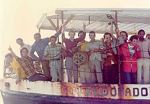

- In 1980 Fidel Castro announced that any Cuban who wanted to leave the country could do so.
- Cubans in the US helped to organize the Mariel Boatlift, which brought 125,000 Cubans to Miami in a few months.
- Miami’s labor force increased by 7% in a few months.
- [Card (1990)](https://www.jstor.org/stable/2523702) used this event to study the effect of an inflow of low-skilled workers on local wages.

## Miami: the Treatment Group

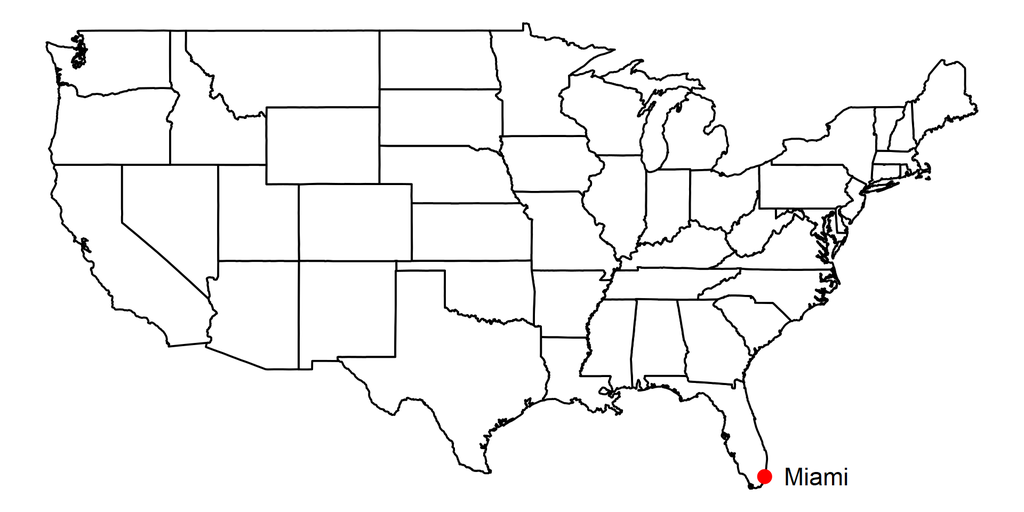

## The Control Group

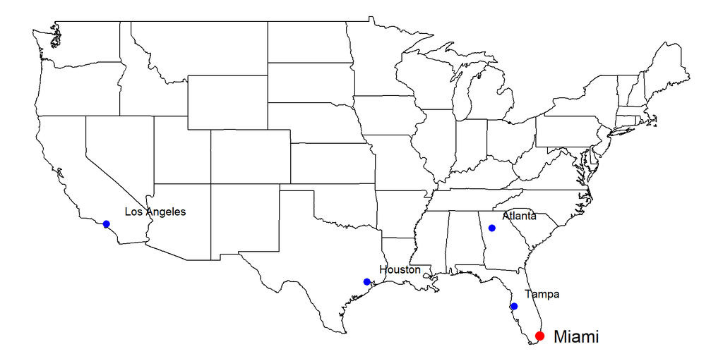

## Card’s Analysis

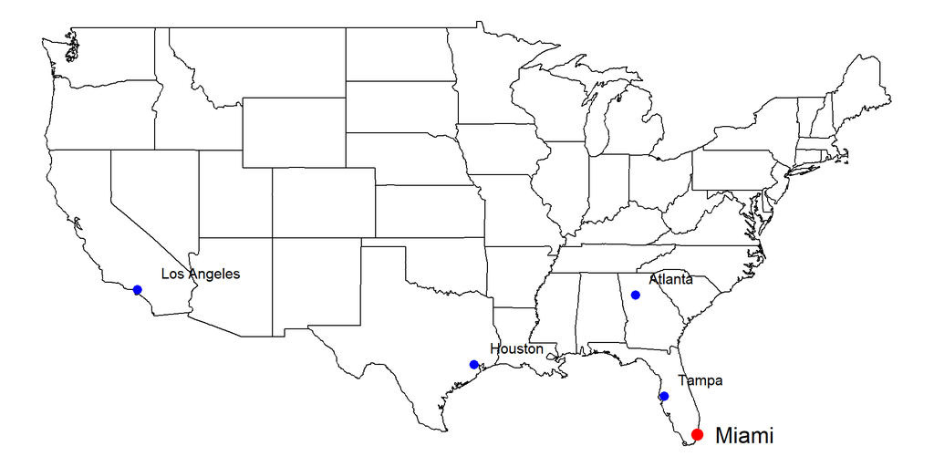

- The analysis compares the evolution of wages in Miami with the evolution of wages in other cities.
- Data from the Current Population Survey, on wages and employment before and after the Mariel Boatlift in Miami and in a set of control cities.

## The Difference-in-Differences Results

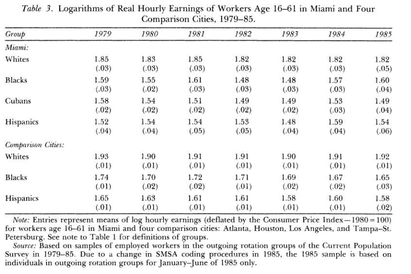

- Card finds no evidence of a negative effect of the Mariel Boatlift on wages in Miami.
- Neither for white nor for African-American workers.

## The Choice of Control Cities

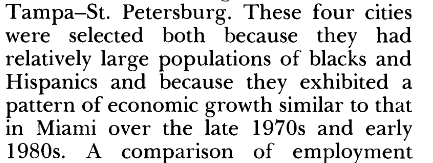

Card (1990, p. 249)

Does this method remind you of something we have seen before?

**→ Difference-in-Differences!** DiD also compares a treated unit to a control group before and after an intervention. SCM generalises this: rather than choosing the control group ad hoc, it *constructs* one as an optimally weighted average of donor units.

# The Synthetic Control Method

## The Idea

- Card’s choice of control cities was arbitrary.
- The synthetic control method removes this arbitrariness.
- The method constructs a synthetic control group for the treated unit that is a weighted average of the *donor pool*.
- The weights are chosen to minimize the difference between the treated unit and the synthetic control group in the pre-treatment period.
- Synthetic control methods are usually used for a single treated unit (a single school, firm, country, etc.).

## The Objective

- Our goal: reproduce the counterfactual of a treated unit by finding the combination of untreated units that best resembles the treated unit before the intervention in terms of the values of $k$ relevant covariates (predictors of the outcome of interest)
- Method selects weighted average of all potential comparison units that best resembles the characteristics of the treated unit(s) - called the *synthetic control*

## Synthetic control method: advantages

- *Convex hull* means synth is a weighted average of units which means the counterfactual is a collection of comparison units that on average track the treatment group over time.
- Constraints on the model use non-negative weights which does not allow for extrapolation
- Makes explicit the contribution of each comparison unit to the counterfactual
- Formalizing the way comparison units are chosen has direct implications for inference

## The Convex Hull Constraint

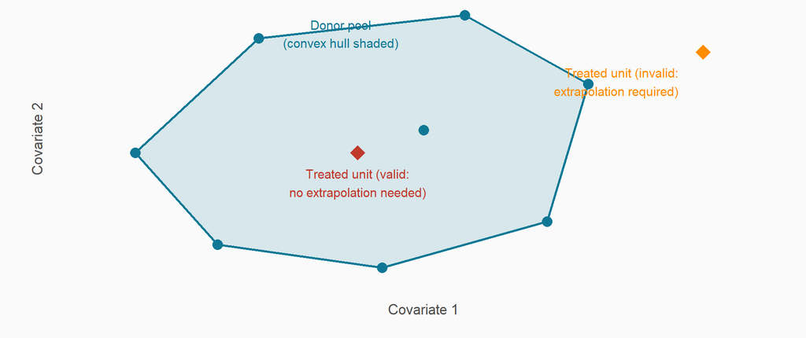

The synthetic control is a **weighted average** of donors ($w_j \geq 0$, $\sum w_j = 1$): it can only represent points **inside** the convex hull. If the treated unit lies outside, no valid set of weights exists — extrapolation is unavoidable.

## Synthetic control method: disadvantages

1. Subjective researcher bias kicked down to the model selection stage
2. Significant diversity at the moment as to how to principally select models - from machine learning to modifications - as well as estimation and software
3. Part of the purpose of this procedure is to reduce subjective researcher bias
4. [Ferman, Pinto and Possebom (2020)](https://onlinelibrary.wiley.com/doi/full/10.1002/pam.22206) suggest specific specifications and report all of them

## Formalization

Suppose that we observe $J + 1$ units in periods $1, 2, . . . , T$

- Unit “one” is exposed to the intervention of interest (that is, “treated”) during periods $T_0 + 1, . . . , T$
- The remaining $J$ are an untreated reservoir of potential controls (a “donor pool”)
- **Key assumptions:** no anticipation of the treatment before $T_0$; no spillovers from the treated unit to the donor pool (SUTVA)

## Optimal Weights

- The synthetic control is a weighted average of the $J$ potential controls
- Let $W = (w_2, \ldots, w_{J+1})′$ with $w_j \geq 0$ for $j = 2, \ldots, J + 1$ and $w_2 + \cdots + w_{J+1} = 1$. Each value of $W$ represents a potential synthetic control
- Let $X_1$ be a $(k \times 1)$ vector of pre-intervention characteristics for the treated unit. Similarly, let $X_0$ be a $(k \times J)$ matrix which contains the same variables for the unaffected units.
- **Step 1:** For a given predictor-weight matrix $V$ (diagonal, $k \times k$), $W^*(V) = (w^*_2, \ldots, w^*_{J+1})′$ minimises $\|X_1 − X_0 W\|_V$, subject to the weight constraints
- **Step 2:** $V$ is then chosen to minimise the pre-treatment mean squared prediction error (MSPE):
  $$\sum_{t=1}^{T_0} \bigg (Y_{1t} - \sum_{j=2}^{J+1}w_j^*(V)\,Y_{jt}\bigg )^2$$

## Estimating the $V$ matrix

Choice of $v_1, . . . , v_k$ can be based on:

- Assess the predictive power of the covariates using regression
- Subjectively assess the predictive power of each of the covariates, or calibration inspecting how different values for $v_1, . . . , v_k$ affect the discrepancies between the treated unit and the synthetic control
- Minimize mean square prediction error (MSPE) for the pre-treatment period (default).

## Optimal Weights: A Toy Example

**3 donors, 2 predictors.** The algorithm must find $W^* = (w_1, w_2, w_3)'$.

**Pre-treatment characteristics**

| Unit | GDP | Unemployment |
| --- | --- | --- |
| **Treated** | **10** | **6** |
| Donor 1 | 12 | 5 |
| Donor 2 | 9 | 7 |
| Donor 3 | 5 | 9 |

**Step 1 — find $W^*$ given $V$**

Suppose $V = \text{diag}(1, 1)$ (equal predictor weights).

$$W^* = \arg\min_W (X_1 - X_0 W)'V(X_1 - X_0 W)$$

Solution: $w_1^* \approx 0.3$, $w_2^* \approx 0.7$, $w_3^* = 0$

Check: $0.3 \times 12 + 0.7 \times 9 = 9.9 \approx 10$ ✓

$\quad\;\;\;\;\;\;\; 0.3 \times 5 + 0.7 \times 7 = 6.4 \approx 6$ ✓

**Step 2 — update $V^*$** to minimise pre-treatment RMSPE over the outcome path; iterate until convergence.

Donor 3 gets zero weight — its profile (GDP = 5, unemployment = 9) is too far from the treated unit.

# The Synthetic Control Method in Practice

## California’s Proposition 99

- In 1988, California first passed comprehensive tobacco control legislation:
  - increased cigarette tax by 25 cents/pack
  - earmarked tax revenues to health and anti-smoking budgets
  - funded anti-smoking media campaigns
  - spurred clean-air ordinances throughout the state
  - produced more than $100 million per year in anti-tobacco projects
- Other states that subsequently passed control programs are excluded from donor pool of controls (AK, AZ, FL, HI, MA, MD, MI, NJ, OR, WA, DC)

## The California Study

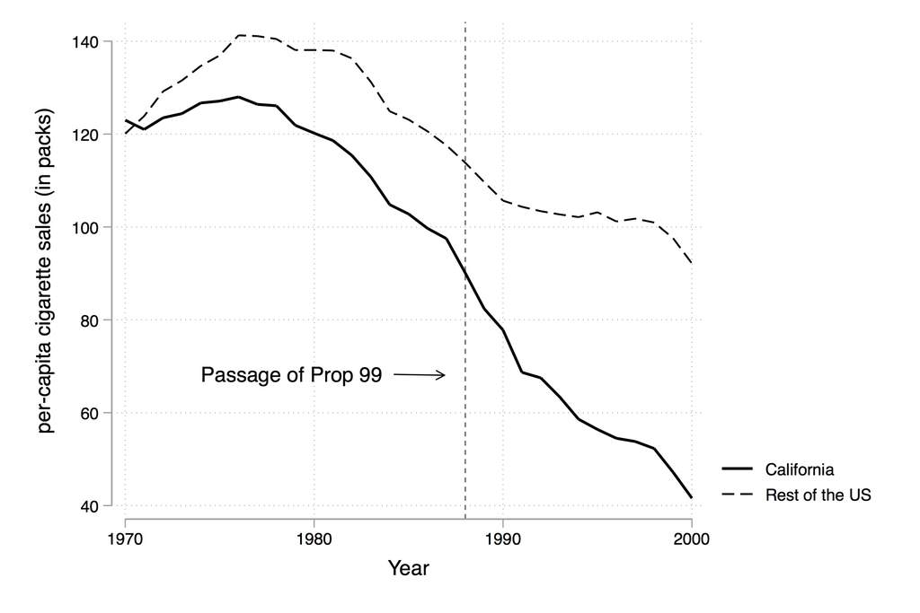

Abadie, Diamond, and Hainmueller (2010) use the synthetic control method to estimate the effect of Proposition 99 on per capita cigarette consumption in California.

## Cigarette Consumption in CA and the Synthetic CA

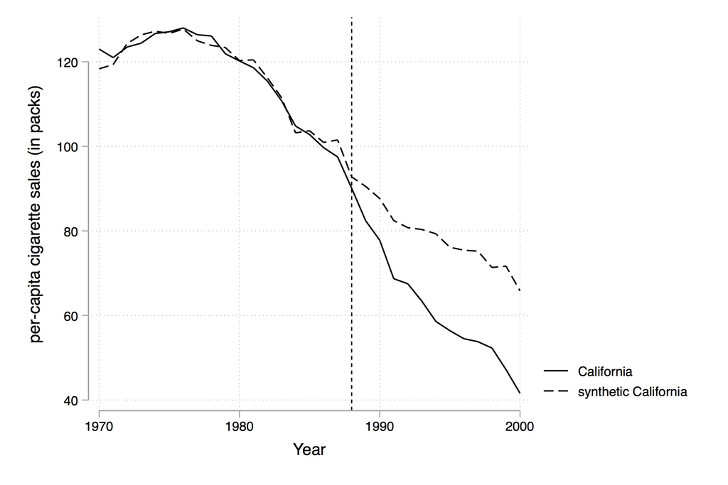

- ADH select 38 states as potential donors
- They select optimal weights to minimize the difference between California and the synthetic California in the pre-treatment period
- Pre-treatment California and synthetic California are very similar
- Post-treatment California and synthetic California diverge

## Synthetic California

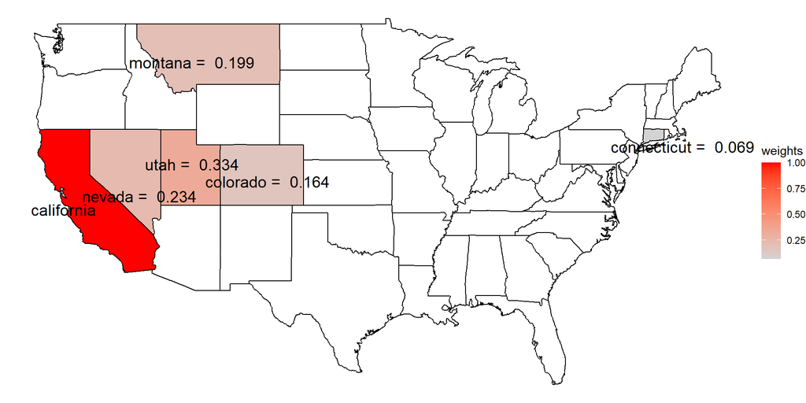

## The Predictors

| Variables | Real California | Synthetic Calif. | Avg. of 38 Control States |
| --- | --- | --- | --- |
| Ln(GDP per capita) | 10.08 | 9.86 | 9.86 |
| Percent aged 15–24 | 17.40 | 17.40 | 17.29 |
| Retail price | 89.42 | 89.41 | 87.27 |
| Beer consumption per capita | 24.28 | 24.20 | 23.75 |
| Cigarette sales per capita 1988 | 90.10 | 91.62 | 114.20 |
| Cigarette sales per capita 1980 | 120.20 | 120.43 | 136.58 |
| Cigarette sales per capita 1975 | 127.10 | 126.99 | 132.81 |

All variables except lagged cigarette sales are averaged for the 1980–1988 period. Beer consumption is averaged 1984–1988.

## CA and Synthetic CA Gap in Cigarette Sales

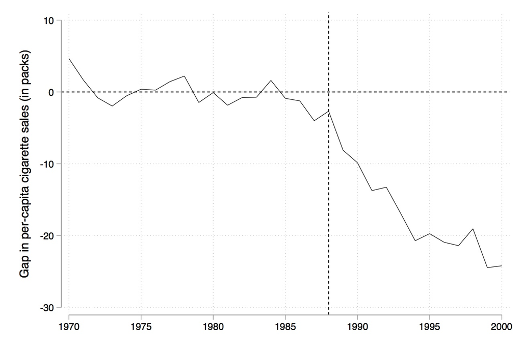

# Inference in Synthetic Control Methods

## The Problem

- We only observe 2 points per year: Hard to determine whether the observed difference between the treated unit and the synthetic control is due to the treatment or to chance
- ADH (2010) use *randomization inference* to test the null hypothesis that the treatment had no effect on the outcome

## Randomization inference

To assess significance, we calculate exact p-values under Fisher’s sharp null using a test statistic equal to after to before ratio of RMSPE

- Exact p-value method
  - Iteratively apply the synthetic method to each country/state in the donor pool and obtain a distribution of placebo effects
  - Compare the gap (RMSPE) for California to the distribution of the placebo gaps. For example the post-Prop. 99 RMSPE is:
    $$RMSPE = \bigg (\dfrac{1}{T-T_0} \sum_{t=T_0+1}^T \bigg (Y_{1t} - \sum_{j=2}^{J+1} w_j^* Y_{jt} \bigg )^2 \bigg )^{\tfrac{1}{2}}$$
    and the exact p-value is the treatment unit rank divided by $J+1$ (the total number of units, including the treated unit)

## Randomization Inference: A Toy Example

*Suppose we have 5 units total (California + 4 donors). Apply SCM to each unit as a placebo treated unit:*

| State | Pre RMSPE | Post RMSPE | Ratio | Rank |
| --- | --- | --- | --- | --- |
| **California** | 3.2 | 24.8 | **7.75** | **1** |
| Nevada | 5.1 | 11.2 | 2.20 | 2 |
| Utah | 4.3 | 8.9 | 2.07 | 3 |
| Colorado | 6.0 | 9.8 | 1.63 | 4 |
| Montana | 5.4 | 7.1 | 1.31 | 5 |

California ranks **1st** out of 5 units $\Rightarrow$ exact p-value $= 1/5 = 0.20$

In ADH (2010): California ranks 1st out of **39** units $\Rightarrow$ p $= 1/39 \approx 0.026$

## Is California Treatment Effect Extreme?

[figure not shown]

Placebo distribution using all units as donor pool

[figure not shown]

Figure 1

## Histogram of post/pre RMSPE of all units.

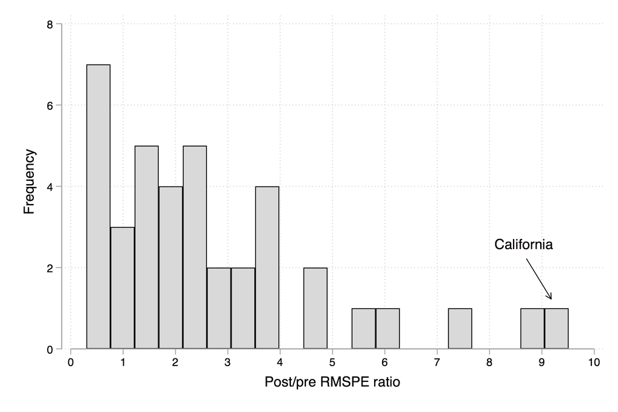

If we were to assign the intervention at random, the probability of obtaining a post/pre-Proposition 99 RMSPE ratio as extreme as the one observed in California is 0.026.

## The Synthetic Marielitos

Remember the Mariel Boatlift? [Peri and Yasenov (2019)](https://jhr.uwpress.org/content/early/2018/01/25/jhr.54.2.0217.8561R1) use the synthetic control method to estimate the effect of the Mariel Boatlift on the Miami labor market.

Findings: no evidence of a negative effect of the Mariel Boatlift on wages in Miami.

# Preconditions and Data Requirements of Synthetic Control Methods

## Preconditions

SCM is a powerful tool, but it is not a panacea. It requires:

1. Big and non-volatile effects;
2. Availability of a good comparison group;
3. No anticipation of the treatment;
4. No spillover effects (SUTVA);
5. Convex hull of the treated unit in the donor pool;

## Data Requirements

1. Aggregate data on predictors and outcomes;
2. Sufficient pre-intervention data;
3. Sufficient post-intervention data.

# Key Takeaways

## Key Takeaways

- **Motivation:** When a single unit is treated (a state, country, firm), DiD with an ad hoc control group is arbitrary. SCM *constructs* the counterfactual optimally.
- **The method:** A synthetic control is a weighted average of donor units, with weights chosen to minimise the pre-treatment gap in outcomes and predictors.
- **Two-step estimation:** Unit weights $W^*$ and predictor weights $V$ are jointly optimised — $V$ governs how predictors are compared, $W^*$ governs how donors are blended.
- **Inference:** Standard asymptotics are unavailable ($J$ small, $T$ moderate). Fisher permutation/randomisation inference — applying SCM to each donor as a placebo — yields an exact $p$-value.
- **Validity:** Requires no anticipation, SUTVA, and that the treated unit lies in the convex hull of the donor pool (no extrapolation).
- **Limitations:** Researcher degrees of freedom at the model-selection stage; works best with many pre-treatment periods and a clearly defined single treated unit.